# Final Project2

Import EDA packages

```r
library(stats)
library(dplyr)
```

```r
library(ggplot2)
library(reshape2)
library(tidyr)
library(randomForest)
library(caret)
library(e1071)
library(ROSE)
library(nnet)
library(NeuralNetTools)
library(psych)
library(rpart)
library(rpart.plot)
library(arules)
```

Import dataframe as strokeData

```r
filePath <- "/Users/linanguyen/Desktop/healthcare-dataset-stroke-data.csv"
strokeData <- read.csv(file = filePath)
```

Statistic summary of strokeData

```r
summary(strokeData)
```

```
##        id           gender               age         hypertension
##  Min.   :   67   Length:5110        Min.   : 0.08   Min.   :0.00000
##  1st Qu.:17741   Class :character   1st Qu.:25.00   1st Qu.:0.00000
##  Median :36932   Mode  :character   Median :45.00   Median :0.00000
##  Mean   :36518                      Mean   :43.23   Mean   :0.09746
##  3rd Qu.:54682                      3rd Qu.:61.00   3rd Qu.:0.00000
##  Max.   :72940                      Max.   :82.00   Max.   :1.00000
##  heart_disease     ever_married        work_type         Residence_type
##  Min.   :0.00000   Length:5110        Length:5110        Length:5110
##  1st Qu.:0.00000   Class :character   Class :character   Class :character
##  Median :0.00000   Mode  :character   Mode  :character   Mode  :character
##  Mean   :0.05401
##  3rd Qu.:0.00000
##  Max.   :1.00000
##  avg_glucose_level     bmi            smoking_status         stroke
##  Min.   : 55.12    Length:5110        Length:5110        Min.   :0.00000
##  1st Qu.: 77.25    Class :character   Class :character   1st Qu.:0.00000
##  Median : 91.89    Mode  :character   Mode  :character   Median :0.00000
##  Mean   :106.15                                          Mean   :0.04873
##  3rd Qu.:114.09                                          3rd Qu.:0.00000
##  Max.   :271.74                                          Max.   :1.00000
```

Remove ‘id’ column from strokeData

```r
strokeData$id <- NULL
```

Counting number of occurences

```r
lapply(strokeData, table)
```

```
## $gender
##
## Female   Male  Other
##   2994   2115      1
##
## $age
##
## 0.08 0.16 0.24 0.32  0.4 0.48 0.56 0.64 0.72  0.8 0.88    1 1.08 1.16 1.24 1.32
##    2    3    5    5    2    3    5    4    5    4    5    5    8    4    8    8
##  1.4 1.48 1.56 1.64 1.72  1.8 1.88    2    3    4    5    6    7    8    9   10
##    3    6    4    8    6    9    8   55   46   34   65   24   32   58   38   35
##   11   12   13   14   15   16   17   18   19   20   21   22   23   24   25   26
##   36   45   57   54   45   52   60   60   50   59   47   45   64   55   57   62
##   27   28   29   30   31   32   33   34   35   36   37   38   39   40   41   42
##   55   54   51   55   79   71   57   68   54   52   76   72   71   74   73   71
##   43   44   45   46   47   48   49   50   51   52   53   54   55   56   57   58
##   70   75   85   62   75   66   79   83   86   90   85   87   83   77   95   68
##   59   60   61   62   63   64   65   66   67   68   69   70   71   72   73   74
##   80   72   76   74   74   53   62   60   49   47   54   45   61   45   46   40
##   75   76   77   78   79   80   81   82
##   53   50   42  102   85   70   60   56
##
## $hypertension
##
##    0    1
## 4612  498
##
## $heart_disease
##
##    0    1
## 4834  276
##
## $ever_married
##
##   No  Yes
## 1757 3353
##
## $work_type
##
##      children      Govt_job  Never_worked       Private Self-employed
```

[output cut: 785 more lines]

```
##    1    1    1    1    2    3    1    2    1    1    4    2    1    1    2    2
## 57.3 57.5 57.7 57.9 58.1 59.7 60.2 60.9 61.2 61.6 63.3 64.4 64.8 66.8 71.9   78
##    1    1    1    1    1    1    1    2    1    1    1    1    1    1    1    1
##   92 97.6  N/A
##    1    1  201
##
## $smoking_status
##
## formerly smoked    never smoked          smokes         Unknown
##             885            1892             789            1544
##
## $stroke
##
##    0    1
## 4861  249
```

Convert BMI from character to numeric, and check for missing values.

```r
strokeData$bmi <- as.numeric(strokeData$bmi)
colSums(is.na(strokeData))
```

```
##            gender               age      hypertension     heart_disease
##                 0                 0                 0                 0
##      ever_married         work_type    Residence_type avg_glucose_level
##                 0                 0                 0                 0
##               bmi    smoking_status            stroke
##               201                 0                 0
```

Drop na in bmi because bmi varies with height and weight, so the average would not best represent the data set. Height and weight are also unknown so bmi cannot be calculated. 201 observations will be deleted, and should not affect the dataset when removing the rows with NA values for bmi.

```r
strokeData <- na.omit(strokeData)
```

Check if na values have been removed

```r
colSums(is.na(strokeData))
```

```
##            gender               age      hypertension     heart_disease
##                 0                 0                 0                 0
##      ever_married         work_type    Residence_type avg_glucose_level
##                 0                 0                 0                 0
##               bmi    smoking_status            stroke
##                 0                 0                 0
```

View the summary statistics.

```r
describe(strokeData)
```

```
##                   vars    n   mean    sd median trimmed   mad   min    max
## gender*              1 4909   1.41  0.49   1.00    1.39  0.00  1.00   3.00
## age                  2 4909  42.87 22.56  44.00   43.17 26.69  0.08  82.00
## hypertension         3 4909   0.09  0.29   0.00    0.00  0.00  0.00   1.00
## heart_disease        4 4909   0.05  0.22   0.00    0.00  0.00  0.00   1.00
## ever_married*        5 4909   1.65  0.48   2.00    1.69  0.00  1.00   2.00
## work_type*           6 4909   3.49  1.28   4.00    3.61  0.00  1.00   5.00
## Residence_type*      7 4909   1.51  0.50   2.00    1.51  0.00  1.00   2.00
## avg_glucose_level    8 4909 105.31 44.42  91.68   97.02 25.86 55.12 271.74
## bmi                  9 4909  28.89  7.85  28.10   28.34  6.97 10.30  97.60
## smoking_status*     10 4909   2.58  1.09   2.00    2.60  1.48  1.00   4.00
## stroke              11 4909   0.04  0.20   0.00    0.00  0.00  0.00   1.00
##                    range  skew kurtosis   se
## gender*             2.00  0.37    -1.85 0.01
## age                81.92 -0.12    -0.99 0.32
## hypertension        1.00  2.83     5.98 0.00
## heart_disease       1.00  4.15    15.25 0.00
## ever_married*       1.00 -0.64    -1.59 0.01
## work_type*          4.00 -0.90    -0.51 0.02
## Residence_type*     1.00 -0.03    -2.00 0.01
## avg_glucose_level 216.62  1.61     1.90 0.63
## bmi                87.30  1.05     3.36 0.11
## smoking_status*     3.00  0.09    -1.35 0.02
## stroke              1.00  4.53    18.52 0.00
```

Plotting the categorical data plots.

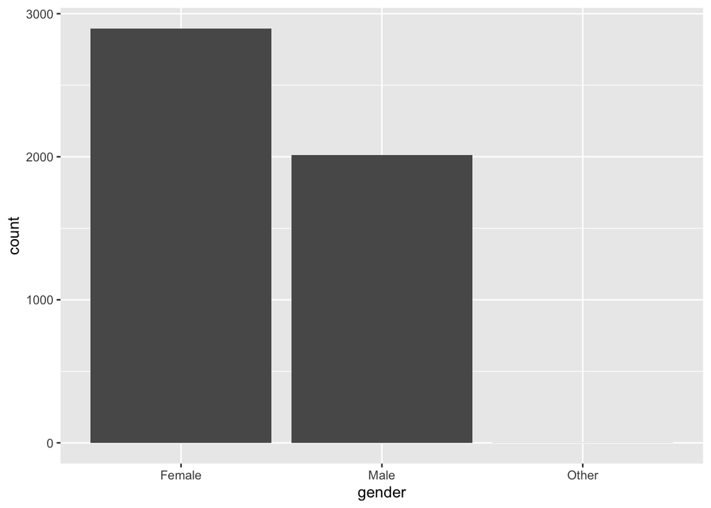

```r
#gender bar plot
genderPlot <- ggplot(data = strokeData) + geom_bar(mapping = aes(x = gender))
genderPlot
```

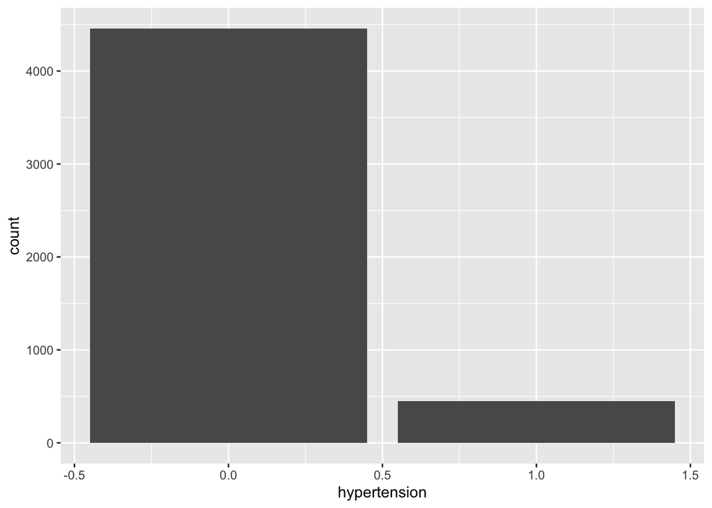

```r
#hypertension bar plot
hypertensionPlot <- ggplot(data = strokeData) + geom_bar(mapping = aes(x = hypertension))
hypertensionPlot
```

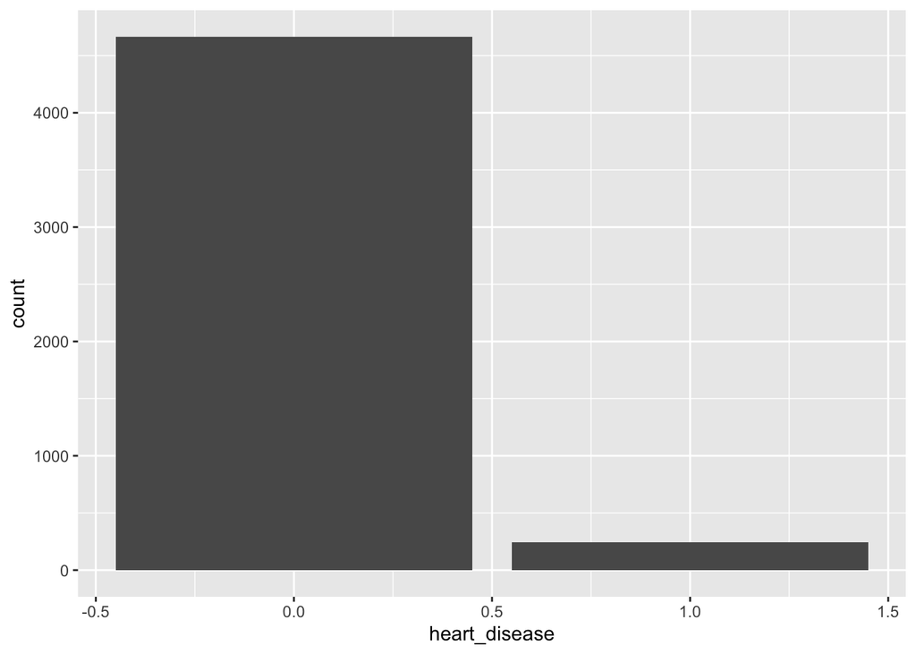

```r
#heart_disease bar plot
heart_diseasePlot <- ggplot(data = strokeData) + geom_bar(mapping = aes(x = heart_disease))
heart_diseasePlot
```

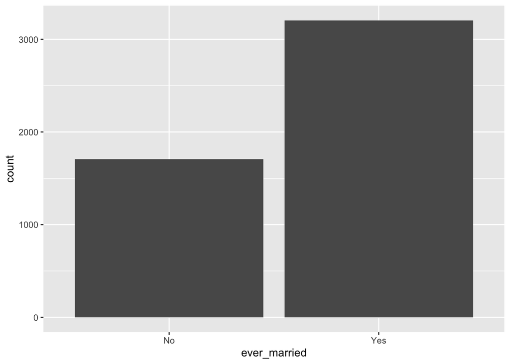

```r
#ever_married bar plot
ever_marriedPlot <- ggplot(data = strokeData) + geom_bar(mapping = aes(x = ever_married))
ever_marriedPlot
```

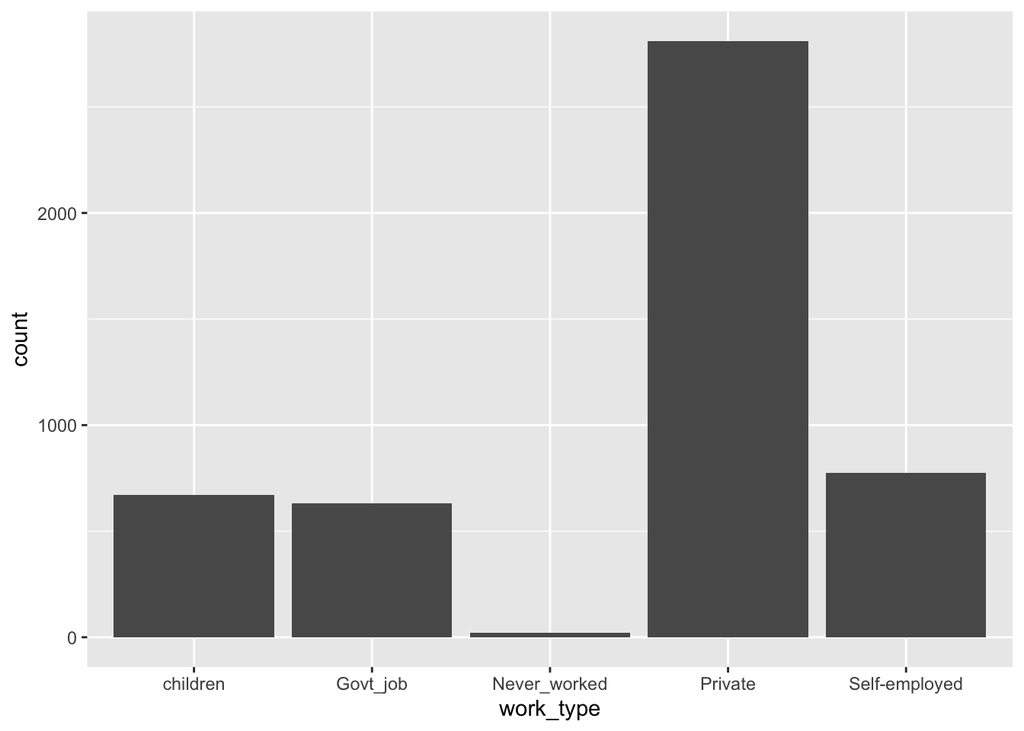

```r
#work_type bar plot
work_typePlot <- ggplot(data = strokeData) + geom_bar(mapping = aes(x = work_type))
work_typePlot
```

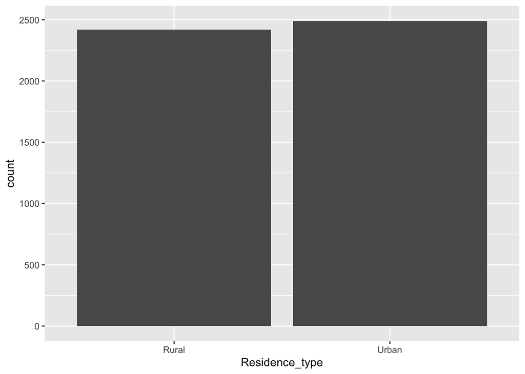

```r
#Residence_type bar plot
Residence_typePlot <- ggplot(data = strokeData) + geom_bar(mapping = aes(x = Residence_type))
Residence_typePlot
```

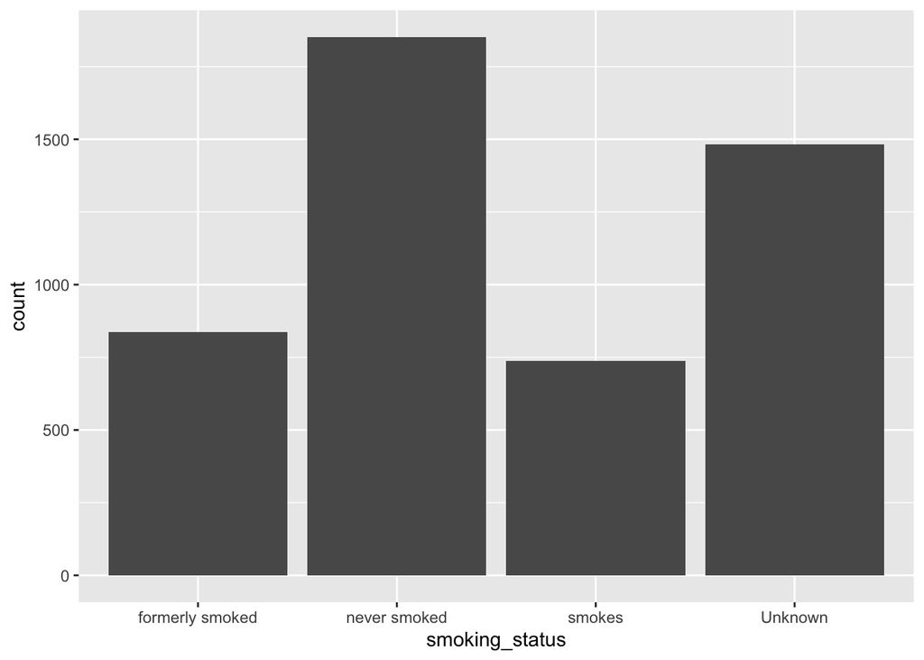

```r
#smoking_status bar plot
smoking_statusPlot <- ggplot(data = strokeData) + geom_bar(mapping = aes(x = smoking_status))
smoking_statusPlot
```

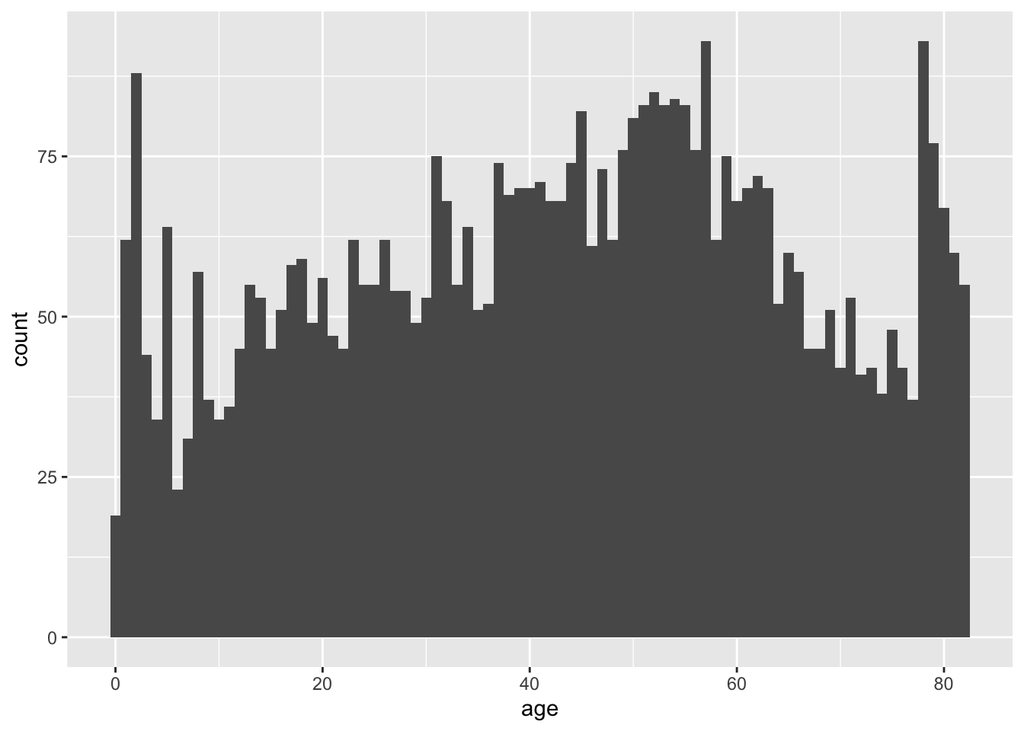

```r
#CONTINUOUS DATA PLOTS
#age, avg_glucose_level, bmi
#age plot
agePlot <- ggplot(data = strokeData) + geom_histogram(mapping = aes(x = age), binwidth = 1)
agePlot
```

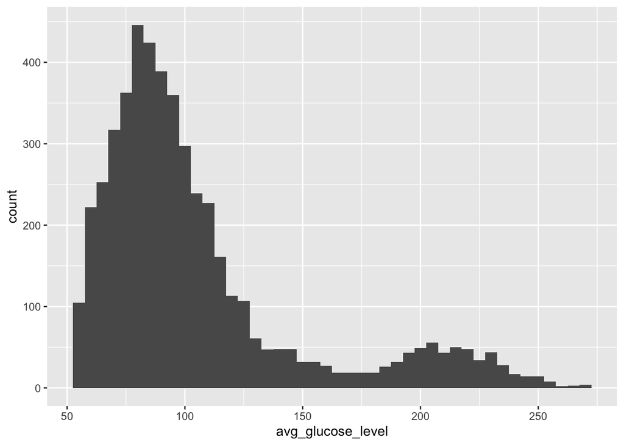

```r
#avg_glucose_level plot
avg_glucose_levelPlot <- ggplot(data = strokeData) + geom_histogram(mapping = aes(x = avg_glucose_level), binwidth = 5)
avg_glucose_levelPlot
```

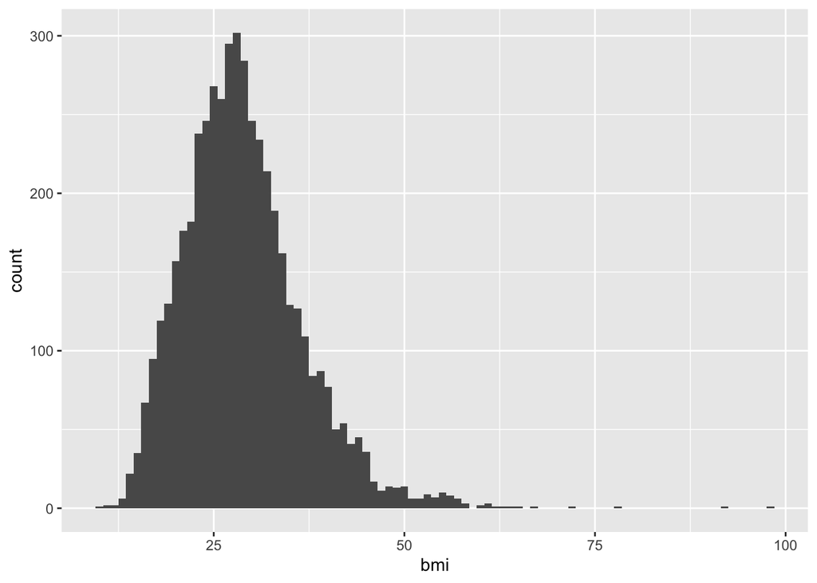

```r
#bmi plot
bmiPlot <- ggplot(data = strokeData) + geom_histogram(mapping = aes(x = bmi), binwidth = 1)
bmiPlot
```

Pairwise comparisons

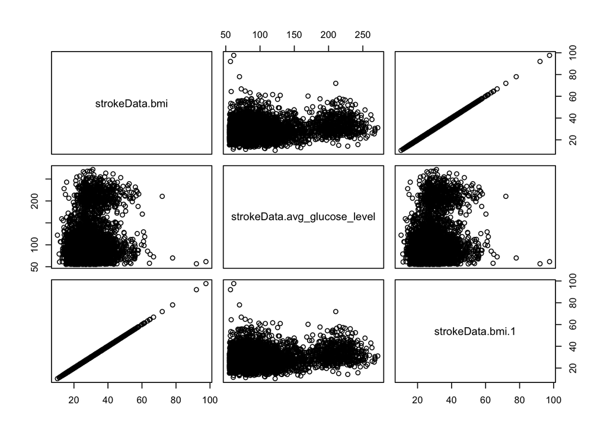

```r
strokeDataNumeric <- data.frame(strokeData$bmi, strokeData$avg_glucose_level, strokeData$bmi)
pairs(strokeDataNumeric)
```

heatmap strokeData

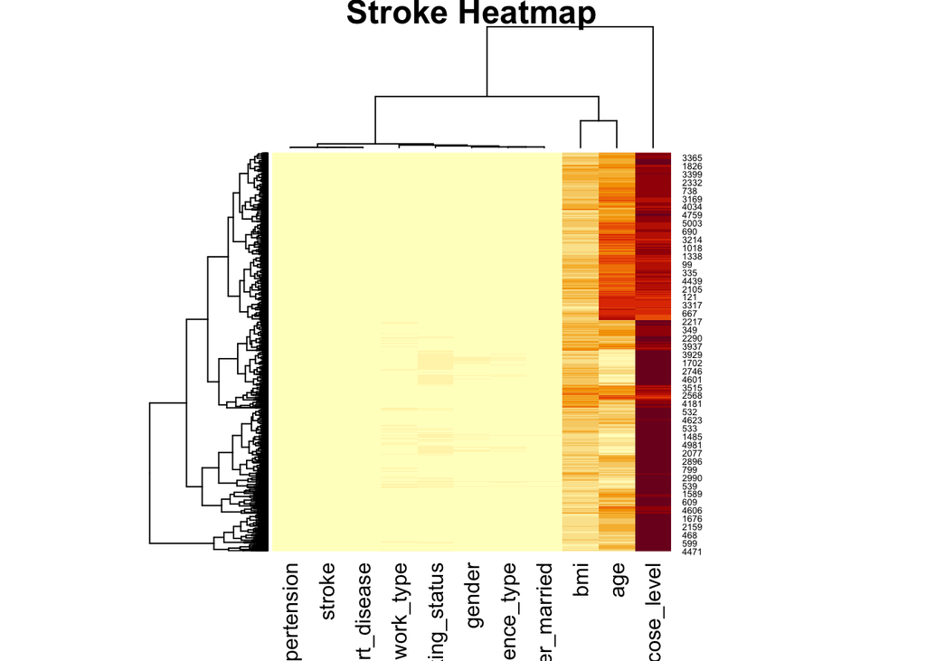

```r
y <- data.matrix(strokeData)
heatmap(y, main = 'Stroke Heatmap', cexRow = 0.5)
```

boxplots of age, avgGlucLevel, and bmi

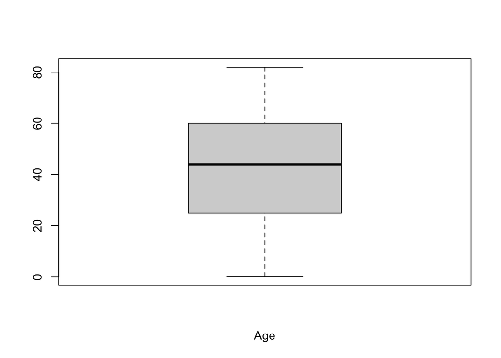

```r
boxplot(strokeData$age, xlab = 'Age')
```

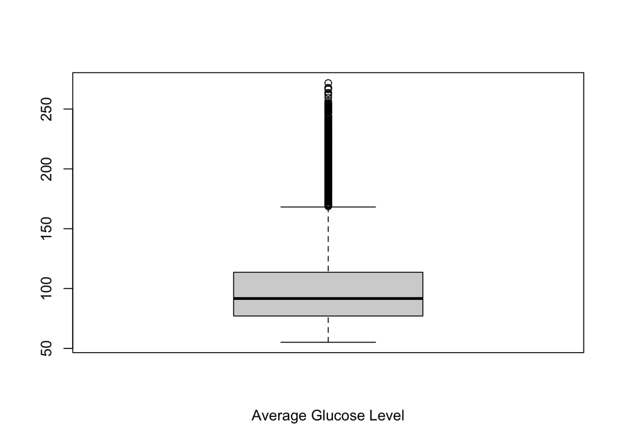

```r
boxplot(strokeData$avg_glucose_level, xlab = 'Average Glucose Level')
```

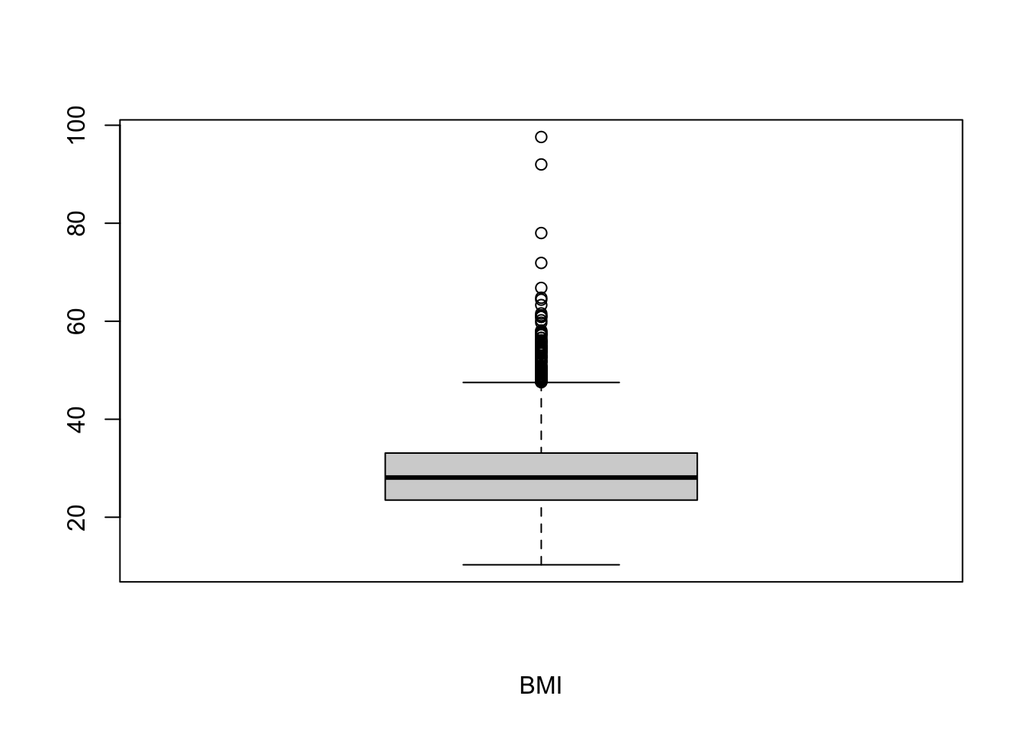

```r
boxplot(strokeData$bmi, xlab = 'BMI')
```

Standardizing the numeric fields (age, avg_glucose_level, bmi)

```r
strokeData$age_z <- scale(x = strokeData$age)
strokeData$avg_glucose_level_z <- scale(x = strokeData$avg_glucose_level)
strokeData$bmi_z <- scale(x = strokeData$bmi)

#Identifying outliers from numeric data
```

```r
ageOutliers <- strokeData[ which(strokeData$age_z < -3 | strokeData$age_z > 3), ]
glucoseOutliers <- strokeData[ which(strokeData$avg_glucose_level_z < -3 | strokeData$avg_glucose_level_z > 3), ]
bmiOutliers <- strokeData[ which(strokeData$bmi_z < -3 | strokeData$bmi_z > 3), ]
```

Preparing the Data to Build Models Partition the data into a training set and testing set

```r
set.seed(8)
n <- dim(strokeData)[1]
train_ind <- runif(n) < 0.75
strokeData_train <- strokeData[ train_ind, ]
strokeData_test <- strokeData[ !train_ind, ]
```

Balancing the training data. Class imbalance problem for stroke. We would rather misclassify a stroke that won’t occur over a stroke that will occur for a stroke that won’t. We will need to balance the data so that we can more accurately predict the outcome.

```r
table(strokeData_train$stroke)
```

```
##
##    0    1
## 3497  157
```

```r
#increase yes's to 25% (from 4%) (resampling 1009 records)
```

```r
to.resample <- which(strokeData_train$stroke == 1)
our.resample <- sample(x = to.resample, size = 1009, replace = TRUE)
our.resample <- strokeData_train[our.resample, ]
strokeData_train_rebal <- rbind(strokeData_train, our.resample)
table(strokeData_train_rebal$stroke)
```

```
##
##    0    1
## 3497 1166
```

Logistic Regression for PCA

```r
#Create a data frame to store logistic regression data
strokeData_logReg <- strokeData_train_rebal
#Run the logistic regression algorithm
logReg01 <- glm(formula = stroke ~ gender + age + hypertension + heart_disease + ever_married + work_type + Residence_type + avg_glucose_level + bmi + smoking_status, data = strokeData_logReg, family = binomial)
summary(logReg01)
```

```
##
## Call:
## glm(formula = stroke ~ gender + age + hypertension + heart_disease +
##     ever_married + work_type + Residence_type + avg_glucose_level +
##     bmi + smoking_status, family = binomial, data = strokeData_logReg)
##
## Deviance Residuals:
##     Min       1Q   Median       3Q      Max
## -2.1518  -0.6239  -0.2614   0.2063   2.6428
##
## Coefficients:
##                              Estimate Std. Error z value Pr(>|z|)
## (Intercept)                -4.938e+00  3.782e-01 -13.055  < 2e-16 ***
## genderMale                 -6.281e-02  8.512e-02  -0.738 0.460597
## genderOther                -1.111e+01  8.827e+02  -0.013 0.989961
## age                         7.560e-02  3.451e-03  21.904  < 2e-16 ***
## hypertension                6.782e-01  1.034e-01   6.560 5.37e-11 ***
## heart_disease               4.378e-01  1.256e-01   3.485 0.000493 ***
## ever_marriedYes             2.387e-02  1.457e-01   0.164 0.869905
## work_typeGovt_job          -1.557e+00  4.077e-01  -3.819 0.000134 ***
## work_typeNever_worked      -1.145e+01  2.430e+02  -0.047 0.962410
## work_typePrivate           -1.578e+00  4.014e-01  -3.931 8.45e-05 ***
## work_typeSelf-employed     -1.862e+00  4.168e-01  -4.467 7.93e-06 ***
## Residence_typeUrban         1.892e-02  8.217e-02   0.230 0.817908
## avg_glucose_level           5.190e-03  7.544e-04   6.880 5.99e-12 ***
## bmi                         1.551e-02  6.549e-03   2.368 0.017892 *
## smoking_statusnever smoked -3.788e-01  1.057e-01  -3.583 0.000340 ***
## smoking_statussmokes        2.937e-01  1.239e-01   2.370 0.017797 *
## smoking_statusUnknown      -3.620e-01  1.318e-01  -2.747 0.006015 **
## ---
## Signif. codes:  0 '***' 0.001 '**' 0.01 '*' 0.05 '.' 0.1 ' ' 1
##
## (Dispersion parameter for binomial family taken to be 1)
##
##     Null deviance: 5244.9  on 4662  degrees of freedom
## Residual deviance: 3686.4  on 4646  degrees of freedom
## AIC: 3720.4
##
## Number of Fisher Scoring iterations: 13
```

Validate the Logisitic regression model

```r
strokeData_logRegTest <- strokeData_test
#Run the logistic regression algorithm
logReg01test <- glm(formula = stroke ~ gender + age + hypertension + heart_disease + ever_married + work_type + Residence_type + avg_glucose_level + bmi + smoking_status, data = strokeData_logRegTest, family = binomial)
summary(logReg01test)
```

```
##
## Call:
## glm(formula = stroke ~ gender + age + hypertension + heart_disease +
##     ever_married + work_type + Residence_type + avg_glucose_level +
##     bmi + smoking_status, family = binomial, data = strokeData_logRegTest)
##
## Deviance Residuals:
##      Min        1Q    Median        3Q       Max
## -1.15860  -0.27246  -0.14785  -0.07375   3.15712
##
## Coefficients:
##                              Estimate Std. Error z value Pr(>|z|)
## (Intercept)                -2.021e+01  7.922e+02  -0.026   0.9796
## genderMale                  1.059e-01  3.229e-01   0.328   0.7430
## age                         7.783e-02  1.229e-02   6.332 2.43e-10 ***
## hypertension                9.166e-01  3.618e-01   2.533   0.0113 *
## heart_disease               7.846e-02  4.717e-01   0.166   0.8679
## ever_marriedYes            -5.028e-01  4.491e-01  -1.120   0.2629
## work_typeGovt_job           1.212e+01  7.922e+02   0.015   0.9878
## work_typeNever_worked      -8.773e-01  3.655e+03   0.000   0.9998
## work_typePrivate            1.287e+01  7.922e+02   0.016   0.9870
## work_typeSelf-employed      1.255e+01  7.922e+02   0.016   0.9874
## Residence_typeUrban         1.740e-01  3.145e-01   0.553   0.5802
## avg_glucose_level           3.656e-04  2.913e-03   0.126   0.9001
## bmi                        -2.046e-02  2.507e-02  -0.816   0.4146
## smoking_statusnever smoked  8.096e-01  4.538e-01   1.784   0.0744 .
## smoking_statussmokes        9.597e-01  5.518e-01   1.739   0.0820 .
## smoking_statusUnknown       2.457e-01  5.672e-01   0.433   0.6648
## ---
## Signif. codes:  0 '***' 0.001 '**' 0.01 '*' 0.05 '.' 0.1 ' ' 1
##
## (Dispersion parameter for binomial family taken to be 1)
##
##     Null deviance: 432.91  on 1254  degrees of freedom
## Residual deviance: 327.59  on 1239  degrees of freedom
## AIC: 359.59
##
## Number of Fisher Scoring iterations: 18
```

Decision Trees

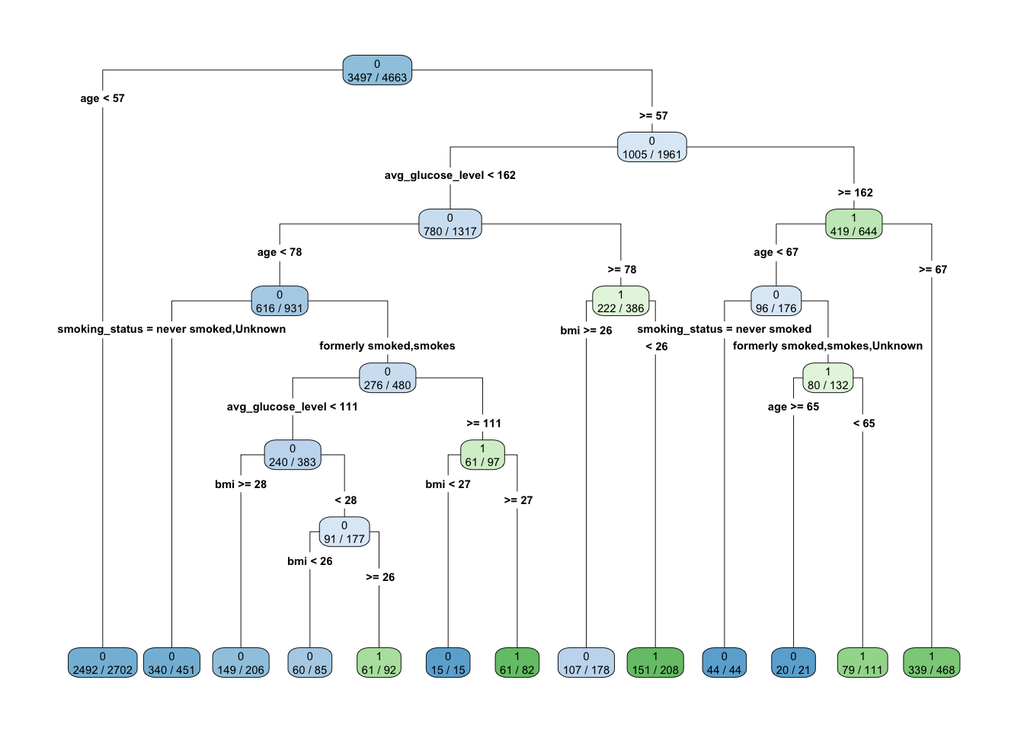

```r
###Create a dataframe to store decision tree data.
strokeData_dt <- strokeData_train_rebal
#change categorical variables to factors (gender, hypertension, heart_disease, ever_married, work_type, residence_type, smoking_status, )
strokeData_dt$hypertension <- factor(strokeData_dt$hypertension)
strokeData_dt$heart_disease <- factor(strokeData_dt$heart_disease)
strokeData_dt$smoking_status <- factor(strokeData_dt$smoking_status)
#decision tree algorithm
dt01 <- rpart(formula = stroke ~ age + hypertension + heart_disease + avg_glucose_level + bmi + smoking_status, data = strokeData_dt, method = "class")
rpart.plot(dt01, type = 4, extra = 2)
```

```r
#obtain the predicted values
predStrokeDT <- data.frame(age = strokeData_dt$age, hypertension = strokeData_dt$hypertension, heart_disease = strokeData_dt$heart_disease, avg_glucose_level = strokeData_dt$avg_glucose_level, bmi = strokeData_dt$bmi, smoking_status = strokeData_dt$smoking_status)
predDt01 <- predict(object = dt01, newdata = predStrokeDT, type = "class")
#Evaluate the training model
trainTableDT <- table(strokeData_dt$stroke, predDt01)
row.names(trainTableDT) <- c("Actual: 0", "Actual: 1")
colnames(trainTableDT) <- c("Predicted: 0", "Predicted: 1")
trainTableDT <- addmargins(A = trainTableDT, FUN = list(Total = sum), quiet = TRUE); trainTableDT
```

```
##            predDt01
##             Predicted: 0 Predicted: 1 Total
##   Actual: 0         3227          270  3497
##   Actual: 1          475          691  1166
##   Total             3702          961  4663
```

Validate the model on the test data

```r
strokeData_dtTest <- strokeData_test
#change categorical variables to factors (gender, hypertension, heart_disease, ever_married, work_type, residence_type, smoking_status, )
strokeData_dtTest$hypertension <- factor(strokeData_dtTest$hypertension)
strokeData_dtTest$heart_disease <- factor(strokeData_dtTest$heart_disease)
strokeData_dtTest$smoking_status <- factor(strokeData_dtTest$smoking_status)
#subset the predictors
predStrokeDTtest <- data.frame(age = strokeData_dtTest$age, hypertension = strokeData_dtTest$hypertension, heart_disease = strokeData_dtTest$heart_disease, avg_glucose_level = strokeData_dtTest$avg_glucose_level, bmi = strokeData_dtTest$bmi, smoking_status = strokeData_dtTest$smoking_status)
#Run the decision tree model on the test data
predDt01test <- predict(object = dt01, newdata = predStrokeDTtest, type = "class")
#Evaluate the training model on TEST data
testTableDT <- table(strokeData_dtTest$stroke, predDt01test)
row.names(testTableDT) <- c("Actual: 0", "Actual: 1")
colnames(testTableDT) <- c("Predicted: 0", "Predicted: 1")
testTableDT <- addmargins(A = testTableDT, FUN = list(Total = sum), quiet = TRUE); testTableDT
```

```
##            predDt01test
##             Predicted: 0 Predicted: 1 Total
##   Actual: 0         1097          106  1203
##   Actual: 1           35           17    52
##   Total             1132          123  1255
```

Neural Networks

```r
#create a dataframe to store neural network data
strokeData_nn <- strokeData_train_rebal
#Convert binary and categorical variables to factors (gender, hypertension, heart_disease, ever_married, work_type, Residence_type, smoking_status, stroke)
strokeData_nn$hypertension <- factor(strokeData_nn$hypertension)
strokeData_nn$heart_disease <- factor(strokeData_nn$heart_disease)
strokeData_nn$smoking_status <- factor(strokeData_nn$smoking_status)
strokeData_nn$stroke <- factor(strokeData_nn$stroke)
#Perform min-max standardization on numeric variables (age, avg_glucose_level, bmi)
strokeData_nn$age.mm <- (strokeData_nn$age - min(strokeData$age)) / (max(strokeData_nn$age) - min(strokeData_nn$age))
strokeData_nn$avg_glucose_level.mm <- (strokeData_nn$avg_glucose_level - min(strokeData_nn$avg_glucose_level)) / (max(strokeData_nn$avg_glucose_level) - min(strokeData_nn$avg_glucose_level))
strokeData_nn$bmi.mm <- (strokeData_nn$bmi - min(strokeData$bmi)) / (max(strokeData_nn$bmi) - min(strokeData_nn$bmi))
#Run the neural network algorithm
nn01 <- nnet(stroke ~ age.mm + hypertension + heart_disease + avg_glucose_level.mm + bmi.mm + smoking_status, data = strokeData_nn, size = 1)
```

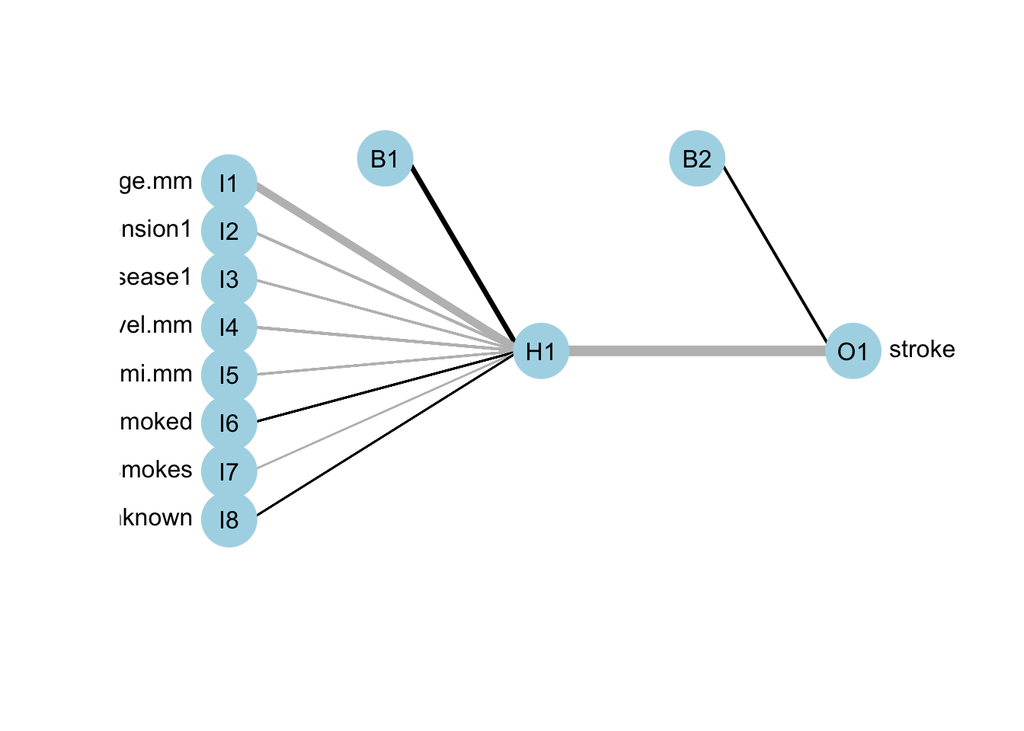

```r
plotnet(nn01)
```

```r
nn01$wts
```

```
##  [1]  2.7280373 -4.4834173 -0.8278710 -0.5615925 -0.9303020 -0.5769567
##  [7]  0.4342614 -0.1161438  0.2898360  1.1503330 -6.7509720
```

```r
#obtain the predicted values
predStrokeNN <- data.frame(age.mm = strokeData_nn$age.mm, hypertension = strokeData_nn$hypertension, heart_disease = strokeData_nn$heart_disease, avg_glucose_level.mm = strokeData_nn$avg_glucose_level.mm, bmi.mm = strokeData_nn$bmi.mm, smoking_status = strokeData_nn$smoking_status)
predNn01 <- predict(object = nn01, newdata = predStrokeNN, type = "class")
#Evaluate the training model
trainTableNN <- table(strokeData_nn$stroke, predNn01)
row.names(trainTableNN) <- c("Actual: 0", "Actual: 1")
colnames(trainTableNN) <- c("Predicted: 0", "Predicted: 1")
trainTableNN <- addmargins(A = trainTableNN, FUN = list(Total = sum), quiet = TRUE); trainTableNN
```

```
##            predNn01
##             Predicted: 0 Predicted: 1 Total
##   Actual: 0         3090          407  3497
##   Actual: 1          529          637  1166
##   Total             3619         1044  4663
```

Validate the model on test data

```r
#Test the model on the test data
strokeData_nnTest <- strokeData_test
#Convert binary and categorical variables to factors (gender, hypertension, heart_disease, ever_married, work_type, Residence_type, smoking_status, stroke)
strokeData_nnTest$hypertension <- factor(strokeData_nnTest$hypertension)
strokeData_nnTest$heart_disease <- factor(strokeData_nnTest$heart_disease)
strokeData_nnTest$smoking_status <- factor(strokeData_nnTest$smoking_status)
strokeData_nnTest$stroke <- factor(strokeData_nnTest$stroke)
#Perform min-max standardization on numeric variables (age, avg_glucose_level, bmi)
strokeData_nnTest$age.mm <- (strokeData_nnTest$age - min(strokeData_nnTest$age)) / (max(strokeData_nnTest$age) - min(strokeData_nnTest$age))
strokeData_nnTest$avg_glucose_level.mm <- (strokeData_nnTest$avg_glucose_level - min(strokeData_nnTest$avg_glucose_level)) / (max(strokeData_nnTest$avg_glucose_level) - min(strokeData_nnTest$avg_glucose_level))
strokeData_nnTest$bmi.mm <- (strokeData_nnTest$bmi - min(strokeData_nnTest$bmi)) / (max(strokeData_nnTest$bmi) - min(strokeData_nnTest$bmi))
#obtain the predicted values
predStrokeNNtest <- data.frame(age.mm = strokeData_nnTest$age.mm, hypertension = strokeData_nnTest$hypertension, heart_disease = strokeData_nnTest$heart_disease, avg_glucose_level.mm = strokeData_nnTest$avg_glucose_level.mm, bmi.mm = strokeData_nnTest$bmi.mm, smoking_status = strokeData_nnTest$smoking_status)
predNn01test <- predict(object = nn01, newdata = predStrokeNNtest, type = "class")
#Evaluate the training model
testTableNN <- table(strokeData_nnTest$stroke, predNn01test)
row.names(testTableNN) <- c("Actual: 0", "Actual: 1")
colnames(testTableNN) <- c("Predicted: 0", "Predicted: 1")
testTableNN <- addmargins(A = testTableNN, FUN = list(Total = sum), quiet = TRUE); testTableNN
```

```
##            predNn01test
##             Predicted: 0 Predicted: 1 Total
##   Actual: 0         1072          131  1203
##   Actual: 1           29           23    52
##   Total             1101          154  1255
```

Association Rules

```r
#create a dataframe to store association rules data
strokeData_ar <- strokeData_train_rebal
#subset the data to only use variables we want rules for
min.strokeData_ar <- subset(strokeData_ar, select = c("age", "hypertension", "heart_disease", "avg_glucose_level", "bmi", "smoking_status", "stroke"))
#Convert binary and categorical variables to factors (hypertension, heart_disease, smoking_status, stroke)
min.strokeData_ar$hypertension <- factor(min.strokeData_ar$hypertension)
min.strokeData_ar$heart_disease <- factor(min.strokeData_ar$heart_disease)
min.strokeData_ar$smoking_status <- factor(min.strokeData_ar$smoking_status)
min.strokeData_ar$stroke <- factor(min.strokeData_ar$stroke)
#generate the association rules
all.rules <- apriori(data = min.strokeData_ar, parameter = list(supp = 0.01, target = "rules", conf = 0.4, minlen = 2, maxlen = 2))
```

```
## Apriori
##
## Parameter specification:
##  confidence minval smax arem  aval originalSupport maxtime support minlen
##         0.4    0.1    1 none FALSE            TRUE       5    0.01      2
##  maxlen target  ext
##       2  rules TRUE
##
## Algorithmic control:
##  filter tree heap memopt load sort verbose
##     0.1 TRUE TRUE  FALSE TRUE    2    TRUE
##
## Absolute minimum support count: 46
##
## set item appearances ...[0 item(s)] done [0.00s].
## set transactions ...[19 item(s), 4663 transaction(s)] done [0.00s].
## sorting and recoding items ... [19 item(s)] done [0.00s].
## creating transaction tree ... done [0.00s].
## checking subsets of size 1 2
```

```
##  done [0.00s].
## writing ... [82 rule(s)] done [0.00s].
## creating S4 object  ... done [0.00s].
```

```r
#view the rules
inspect(head(all.rules, by = "lift", n = 10))
```

```
##      lhs                         rhs                           support
## [1]  {heart_disease=1}        => {stroke=1}                    0.05146901
## [2]  {heart_disease=1}        => {age=[61,82]}                 0.07076989
## [3]  {hypertension=1}         => {stroke=1}                    0.07034098
## [4]  {stroke=1}               => {age=[61,82]}                 0.17242119
## [5]  {age=[61,82]}            => {stroke=1}                    0.17242119
## [6]  {heart_disease=1}        => {avg_glucose_level=[110,272]} 0.05361355
## [7]  {hypertension=1}         => {age=[61,82]}                 0.08535278
## [8]  {age=[0.08,38)}          => {bmi=[10.3,26.1)}             0.18807635
## [9]  {bmi=[10.3,26.1)}        => {age=[0.08,38)}               0.18807635
## [10] {smoking_status=Unknown} => {age=[0.08,38)}               0.14711559
##      confidence coverage  lift     count
## [1]  0.6138107  0.0838516 2.454717 240
## [2]  0.8439898  0.0838516 2.442908 330
## [3]  0.5198098  0.1353206 2.078793 328
## [4]  0.6895369  0.2500536 1.995848 804
## [5]  0.4990689  0.3454857 1.995848 804
## [6]  0.6393862  0.0838516 1.917336 250
## [7]  0.6307448  0.1353206 1.825676 398
## [8]  0.5866221  0.3206090 1.765926 877
## [9]  0.5661717  0.3321896 1.765926 877
## [10] 0.5613748  0.2620630 1.750964 686
```

```r
#determine the rules where stroke in antecedent
all.rules.ant.df <- as(as(attr(all.rules, "lhs"), "transactions"), "data.frame")
t1 <- all.rules.ant.df$items == "{stroke=1}"
t2 <- all.rules.ant.df$items == "{stroke=0}"
non.stroke.ant <- abs(t1 + t2 - 1)
good.rules <- all.rules[non.stroke.ant == 1]
inspect(head(good.rules, by = "lift", n = 25))
```

```
##      lhs                                 rhs
## [1]  {heart_disease=1}                => {stroke=1}
## [2]  {heart_disease=1}                => {age=[61,82]}
## [3]  {hypertension=1}                 => {stroke=1}
## [4]  {age=[61,82]}                    => {stroke=1}
## [5]  {heart_disease=1}                => {avg_glucose_level=[110,272]}
## [6]  {hypertension=1}                 => {age=[61,82]}
## [7]  {age=[0.08,38)}                  => {bmi=[10.3,26.1)}
## [8]  {bmi=[10.3,26.1)}                => {age=[0.08,38)}
## [9]  {smoking_status=Unknown}         => {age=[0.08,38)}
## [10] {age=[0.08,38)}                  => {smoking_status=Unknown}
## [11] {smoking_status=formerly smoked} => {age=[61,82]}
## [12] {smoking_status=Unknown}         => {bmi=[10.3,26.1)}
## [13] {bmi=[10.3,26.1)}                => {smoking_status=Unknown}
## [14] {hypertension=1}                 => {avg_glucose_level=[110,272]}
```

[output cut: 37 more lines]